# EviewsR: An R Package for Dynamic and Reproducible Research Using EViews, R, R Markdown and Quarto

Sagiru Mati

Near East University

Irfan Civcir

Ankara University

S. I. Abba

King Fahd University of Petroleum and Minerals

2023-11-01

Abstract

EViews is a software designed for conducting econometric data analysis. There exists a one-way communication between EViews and R, as the former can run the code of the latter, but the reverse is not the case. We describe EviewsR, an R package which allows users of R, R Markdown and Quarto to execute EViews code. In essence, EviewsR does not only provide functions for base R, but also adds EViews to the existing knitr’s knit-engines. We also show how EViews equation, graph, series, and table objects can be imported and customised dynamically and reproducibly in R, R Markdown and Quarto document. Therefore, EviewsR seeks to improve the accuracy, transparency and reproducibility of research conducted with EViews and R.

[output not shown]

# Introduction

EViews, which stands for Econometric Views, is software designed for econometric analysis. EViews provides powerful statistical, time series, forecasting, and modelling tools through an innovative, easy-to-use object-oriented interface (Startz 2019). The software can be operated via its built-in menu, code or scripts saved in a file with the `.prg` extension. Although EViews is programmable, it lacks some routines to estimate new econometric techniques. For this reason, the users of EViews have to resort to using R for routines that are available in R but not yet implemented in EViews. This process involves having to switch between R and EViews, which hinders reproducibility and can lead to errors. EViews can open and run R code, but the converse is not true. An R package (Murrell 2019) has been created to facilitate importing EViews workfile data to R. The package is limited as it cannot run EViews code from within the R environment. Another R package (Pretis, Reade, and Sucarrat 2018) allows exporting R object to EViews program via the package’s function `eviews(object, file=NULL, print=TRUE, return=FALSE)`. Still, package does not allow embedding EViews code in R Markdown and Quarto. Xie (2019) had created the R package , which allows communication between R and other statistical applications such as Stata and Octave, or programming languages such as Julia and Python. The statistical application and programming languages supported by the package are called knit-engines, and EViews is not one of them. Users can view the existing languages by running the following code in R console: `names(knitr::knit_engines$get())`. Another major challenge is that EViews does not support markdown syntax. To address these problems, we created an R package (Mati 2019b) which integrates EViews and R. Basically, provides base R functions and additional ’s knit-engine for EViews.

The package is designed to be useful for all users of EViews, R, R Markdown and Quarto. The package allows EViews users to comfortably work in R, R Markdown or Quarto and have access to the ecosystems of all the applications. For example, they can make their document dynamic. On the other hand, the users of R, R Markdown and Quarto can easily benefit from the unique EViews’s statistical or econometric routines and appealing graphics. For example, they can easily plot a line graph from an undated R dataframe (`dataFrame`) by `EviewsR::eviews_graph(dataFrame,start_date=1990)`, which may need several lines of code in base R. EViews has some advantages over R: 1. code stability. EViews has standard syntax and documentation and offers backward compatibility of code so that code does not break; 2. it also generates corresponding code for each menu action; 3. better support for econometric models; 4. easier to customise graphs. EViews graphs can be edited using the graphical user interface (GUI) and get the corresponding code generated by EViews; 5. stronger support for timeseries and panel data. Thus, teachers of Econometrics can spend more time on teaching Econometrics than on teaching software. EviewsR package helps EViews users to use R Markdown or Quarto without having to learn R functions for estimation and graphing.

Research is reproducible if its scientific computations can be replicated by an independent researcher (Stodden, Leisch, and Peng 2014). On the other hand, interactive reports entail the ability of a computational output to reactively change with the changes in input(s). For example, the output of an input `2+2` is 4. This output is expected to change automatically to 8 when the input changes to `3+5`. Modification of figures, tables, bibliography, captions and other objects becomes very easy in dynamic documents. Xie (2014) provides a detailed explanation and implementation of dynamic documents with R.

Sandve (2013) discuss ten simple rules that will ensure reproducibility of computational research. Some of these rules include avoiding manual data manipulation steps, use of version control and providing public access to scripts and results. Christensen and Miguel (2018) examines the transparency, reproducibility, and credibility of Economics research, revealing evidence of result non-replicability within the field. The interest in reproducibility of research has traversed various fields of STEM and social sciences (see for example Franco, Malhotra, and Simonovits 2014; Simmons, Nelson, and Simonsohn 2011; Gerber et al. 2014; Harvey, Liu, and Zhu 2015; Ioannidis 2005). The aforementioned studies emphasise on the need for guidelines and solid criteria to ensure reproducibility of research. Therefore this article can help ensure replicability and reproducibility of research in the fields that employ EViews and R for their computations.

We categorise the reproducibility of research into three: 1. sharing the data and providing an easy guide on how to implement the computations 2. sharing the data, text and software code in separate files 3. sharing the data, the text and code in a single file. This paper aims to implement the third aspect of reproducibility using EViews, R, R Markdown and Quarto.

We intend to contribute to the current theme of dynamic and reproducible research as follows. We have created an R package , which does not only integrate EViews and R, but also adds `eviews` as a new knit-engine for the package. We also show how to create and modify EViews `equation`, `graph`, `series` and `table` objects dynamically and reproducibly. EViews code can now be embedded in R Markdown and Quarto documents so that both R and EViews users can collaborate on a single document. The package also provides R functions that could be used to 1. graph EViews series objects 2. graph an R dataframe using EViews 3. import data from external sources such as csv, xlsx as a new EViews workfile or into an existing workfile 4. create an EViews workfile from an R dataframe 5. save an EViews workfile or page as a workfile or another file format 6. execute EViews code 7. export an R dataframe as a new EViews workfile or to an existing EViews workfile 8. import EViews table object as `kable` 9. import EViews series objects as a dataframe or xts object 10. import EViews equation data members, `graph`, `series` and `table` objects 11. simulate a random walk process using EViews. We finally show how to use existing EViews workfiles in a dynamic document in order to avoid repeating time-consuming computations.

The rest of the article is structured as follows. We provide an overview of EViews, R, R Markdown and Quarto in Section @ref(sec-tools). The description of the package is in Section @ref(sec-eviewsr). We briefly explain how to use the package along with R, R Markdown and Quarto in Sections @ref(sec-document) and @ref(sec-base). Section @ref(sec-dynamic) is dedicated to the implementation of dynamic document, Section @ref(sec-implementation) to the package implementation, while Section @ref(sec-conclusion) covers the summary and conclusion.

# EViews, R, R Markdown and Quarto

EViews (Econometric Views) is a statistical tool that facilitates both time-series and panel data analyses[^1]. It can be operated using GUI, command or a program containing a set of commands.

R, on the other hand, is a free and open-source statistical programming language developed and maintained by R Core Team (2019)[^2]. Unlike the EViews, the R software is command-based, implying that every output is generated by executing a command or a set of commands. Thus, reproducing any outputs is as easy as running the code in the R console. Base R’s functionality can be extended via custom-made functions and objects, that can be organized into R packages. The R packages are available for free to download at Comprehensive R Archive Network (CRAN)[^3].

RStudio is an Integrated Development Environment (IDE) for the R. It simplifies the use of the R as some of the R code can be executed via the GUI drop-down menus in RStudio[^4]. In addition to that, RStudio works as an efficient plain text editor; it is easy and straightforward to edit text files with extensions such as `bib`, `tex`, `Rmd`, `Rmarkdown`, `md`, `yaml` and several other extensions.

R Markdown provides an easy way to write a markdown document (Allaire et al. 2020). It is available in RStudio with two alternative extensions: Rmd and Rmarkdown. It facilitates the ability to combine Markdown syntax with the syntax of R and other programming languages supported by the package. Users can easily create R Markdown documents in RStudio by clicking `File-> New File-> R Markdown`. R Markdown documents consist of three components: metadata, text and code (Xie 2015). Metadata, also known as YAML metadata or YAML frontmatter, is written in-between a pair of three dashes. It can contain the author name, output format, title and so on (see Xie 2014, 2015, 2019)

```
---
title: 'An Example of YAML metadata'
author: "Author Name"
output: bookdown::pdf_document2
---
```

After the above YAML metadata, text and code follow until the end of the R Markdown document. Text syntax is just like plain Markdown syntax, but code has to be placed inside blocks delimited by backticks. Note that we use `bookdown::pdf_document2` as the output because it allows for cross-reference in an R Markdown document.

Quarto is the “next generation version of R Markdown” developed by RStudio team. It is an open-source scientific and technical publishing system built on Pandoc. Unlike R Markdown, Quarto can be used to create dynamic content with Python, R, Julia, and Observable and work with IDEs such as VS code, RStudio, Jupyter and Text Editor[^5]. The extension of Quarto file is `.qmd`.

## Code chunks

The ability to embed R code is the major difference between an R Markdown/Quarto document and a Markdown document. R code can easily be embedded in R Markdown and Quarto documents. The R package extends this capability to allow users to embed the code of other programming languages such as Python and Go, or other statistical packages such as Stata and Octave. A minimal example of R code chunk looks like the following

````
```{r chunkLabel,eval=TRUE,echo=FALSE}
y=runif(100)
```
````

Or in YAML format:

````
```{r}
#| label: chunkLabel
#| eval: true
#| echo: false
y=runif(100)
```
````

R chunk starts with three back-ticks, followed by curly braces containing the knit-engine, chunk label, chunk options, R code and ends with three back-ticks. In the chunk above, `r` is the engine name (knit-engine), `chunkLabel` is an arbitrary but unique text that gives the chunk a name, `eval=TRUE` and `echo=FALSE` are some examples of chunk options, `y=runif(100)` is a typical R code. If `r` is replaced with `eviews` in the chunk above, we will refer to the chunk as an EViews code chunk, not an R code chunk. We will continue to use the YAML format since both R Markdown and Quarto accept it.

We use prompts like `"EViews >"` and `"R >"` to represent code written in EViews and R respectively. We use `"-"` and `"+"` to signify continuation of EViews and R code respectively. Therefore `"+ -"` stands for continuation of EViews code written within R function. Code chunk indicates code written in an R Markdown or Quarto document.

# About EviewsR

is an R package to integrate EViews and base R, and also built on top of package (Xie 2014, 2015, 2019) to add new knit-engine. It allows users of base R to communicate with EViews via R functions and users of R Markdown to embed EViews code chunks in an R Markdown document.

## How to configure EViews before using EviewsR

To run the package successfully, users need to do one of the following:

1. Do not change anything if the name of the EViews executable is one of the following: `EViews12_x64`, `EViews12_x86`, `EViews11_x64`, `EViews11_x86`, `EViews10_x64`, `EViews10_x86`, `EViews9_x64`, `EViews9_x86`. The package will find the executable automatically.
2. Rename the EViews executable to `eviews` or one of the names above.
3. Alternatively, you can use `set_eviews_path()` function to set the path to the EViews executable as follows:

```r
R> set_eviews_path("C:/Program Files (x86)/EViews 10/EViews10.exe")
```

Or

```r
R> set_eviews_path("C:\\Program Files (x86)\\EViews 10\\EViews10.exe")
```

The backslash symbol (\) is used as a special escape symbol in R strings, so in order to write a literal backslash we need to precede it with another backslash.

## How to use EviewsR

The package can be used along with base R, R Markdown or Quarto document. Users should start by loading the package via R console or by creating an R chunk in an R Markdown or Quarto document as shown below:

````
```{r EviewsRPackage,echo=FALSE}
if(!require("EviewsR")) install.packages("EviewsR")
library(EviewsR)
```
````

Figure @ref(fig:fig-flowchart) presents a chart showing the steps and requirements to use package.

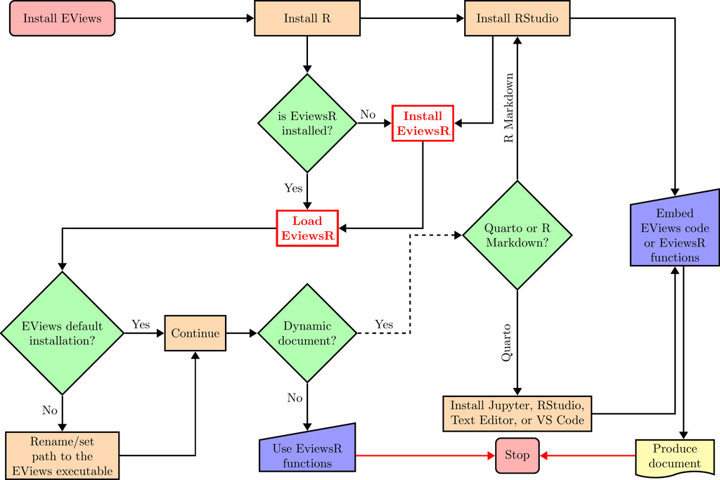

Setting up EviewsR, EViews, R, R Markdown and Quarto

# EviewsR: R Markdown and Quarto document

As mentioned earlier, the package adds `eviews` as a knit-engine to package. Therefore, it allows users to embed EViews code in an R Markdown or Quarto document. After loading the package, then create an EViews chunk as shown below:

````
```{eviews}
#| label: fig-EviewsR
#| graph: ""
#| eval: true
#| echo: false


  'This is some comment in EViews program, feel free to write anything

  wfcreate(wf=EviewsR,page=EviewsR) m 2000 2022

  for %y EviewsR1 EviewsR2
  pagecreate(page={%y}) m 2000 2022
  next

  for %y EviewsR EviewsR1 EviewsR2

  pageselect {%y}

  genr y=@cumsum(nrnd)
  genr x=@cumsum(nrnd)

  graph x_graph.line(o=eviews5) x
  graph y_graph.dot(o=bokeh) y

  table EviewsRTable

  for !j=1 to 7
  EviewsRTable(1,{!j})="Header"+" "+@str({!j})
  next

  for !i=1 to 10
  for !j=1 to 7
  EviewsRTable({!i}+1,{!j})=@str({!i})+","+@str({!j})
  next
  next

  next

  wfsave EviewsR_files/EviewsR
```
````

The chunk options available for EviewsR package in R Markdown and Quarto documents

| Chunk option | Default value | Possible values | Example | Meaning |
| --- | --- | --- | --- | --- |
| equation | `*` | Any valid name pattern for EViews `@wlookup` function | `eq*, ??e, *e*` | EViews equation object |
| graph | `*` | asis, first, last, asc, desc, or any valid name pattern for EViews `@wlookup` function | `gr*, g??, *t*` | EViews graph object |
| series | `*` | Any valid name pattern for EViews `@wlookup` function | `se*, ?e?, *y*` | EViews series object |
| table | `*` | Any valid name pattern for EViews `@wlookup` function | `ta*, ?t, *s*` | EViews table object |
| page | `*` | Any valid name pattern for EViews `@wlookup` function | page1, page2, page3, page4, page5 | EViews page |
| graph_procs |  | Any valid EViews graph’s procedure | align(2,1,1) | EViews graph’s procedure |
| save_options |  | Any valid options for EViews save command | t=pdf, -c | EViews options for graph save command |
| class | df | xts |  | Class of R’s object for imported EViews series objects |
| save_path |  | Any valid path | C:/Users/EviewsR | Path to save EViews graphs |

# EviewsR: Dynamic Document

This section is about working with EViews’s equation, graph, series and table objects dynamically in an R Markdown or Quarto document.

## Accessing EViews objects from EViews chunk

The EViews chunk below (`label: fig-EviewsR1`) contains EViews code which generates a workfile named `EviewsR_workfile` along with a page `EviewsR_page` with monthly frequency from 2000 2022. The chunk also creates additional three EViews pages (`page1`, `page2`, and `EviewsR`) and generates three series objects $x$, $y$ and $z$. It then runs the ordinary least square (OLS) method with $y$ as the dependent variable and the rest as independent variables on each of the new pages. On each of the new pages, an equation, a table and three graph objects are created. The equation object is defined as `OLS`, the table object as `OLS_TABLE` and three graph objects as `graph1`, `graph2` and `graph3`.

The chunk automatically creates a new environment with the chunk’s label as the environment’s name, then returns all the EViews’s equation, series and table objects into R as a dataframe saved within the new environment. Note that the chunk label (`fig-EviewsR1`) is not a valid R object, so removes the prefix `fig-` before creating the new environment as `EviewsR1`. The prefix (`fig-`) is added to the chunk label because it is the Quarto’s default way to wrap plots contained in a chunk in a figure environment for cross-reference. If you are working with R Markdown or the chunk does not contain EViews graph objects, you do not need to add the prefix.

The contents of the EViews `table` objects are imported into R exactly as they are on the EViews workfile, but the table name is changed to small letters. You can use the following format to get the imported table:

- `chunkLabel$pageName_tableName`

The `chunkLabel` stands for the chunk label and is the new environment, `pageName` for the EViews page name and `tableName` for the EViews table object. Therefore, `EviewsR1$eviewsr_ols_table` accesses the table `ols_table`, which is imported from `EviewsR` page of chunk `EviewsR1` into R as a dataframe.

````
```{eviews}
#| label: fig-EviewsR1
#| fig.cap: EViews graphs automatically imported by EViews chunk (fig-EviewsR1: default chunk options)
#| out.width: 32%
#| out.height: 15%
#| fig.ncol: 3
#| echo: false
#| eval: true

'This is some comment in EViews program, feel free to write anything

wfcreate(page=EviewsR_page,wf=EviewsR_workfile) m 2000 2022

!n=123

for %y page2 EviewsR  page1
pagecreate(page={%y}) q 2000 2022
pageselect {%y}
rndseed !n
!n=!n+100

genr x=@cumsum(nrnd)
genr y=@cumsum(nrnd)
genr z=@cumsum(nrnd)
equation OLS.ls y c x z
freeze(OLS_TABLE,mode=overwrite) OLS
delete(noerr) GRAPH*
freeze(GRAPH3,mode=overwrite) z.line
graph GRAPH2.dot y
graph GRAPH1.area x
graph3.addtext(ar) %y
graph2.addtext(ar) %y
graph1.addtext(ar) %y
next
```
````

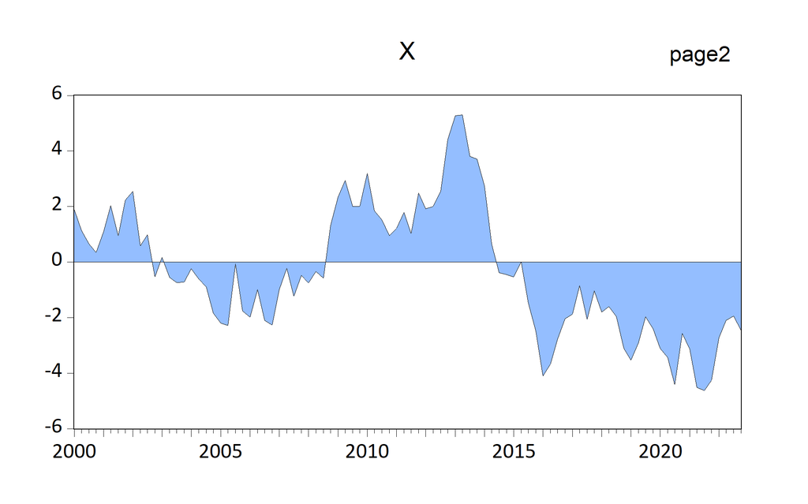

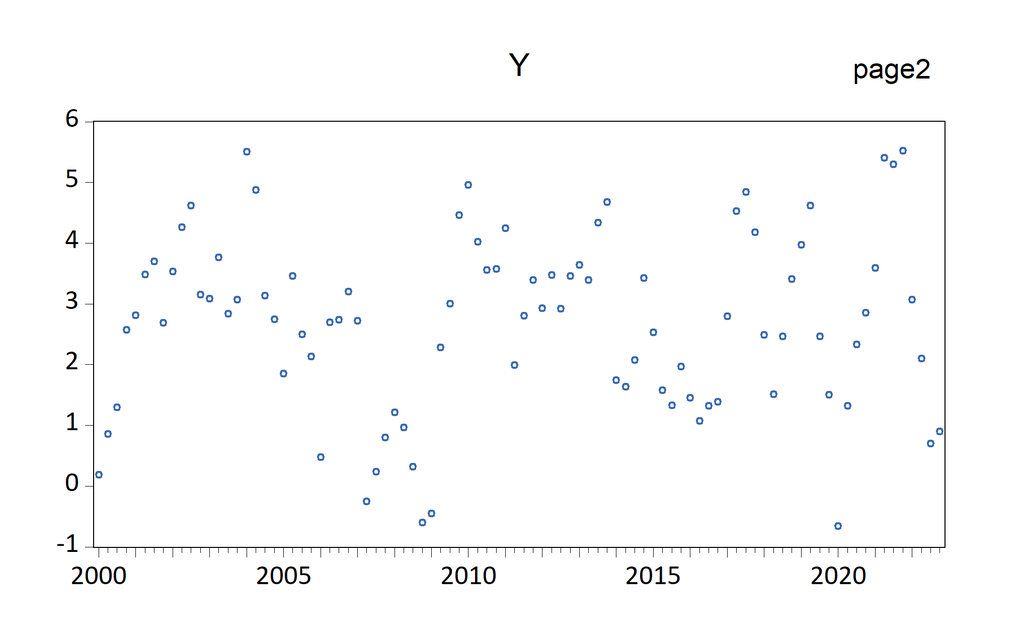

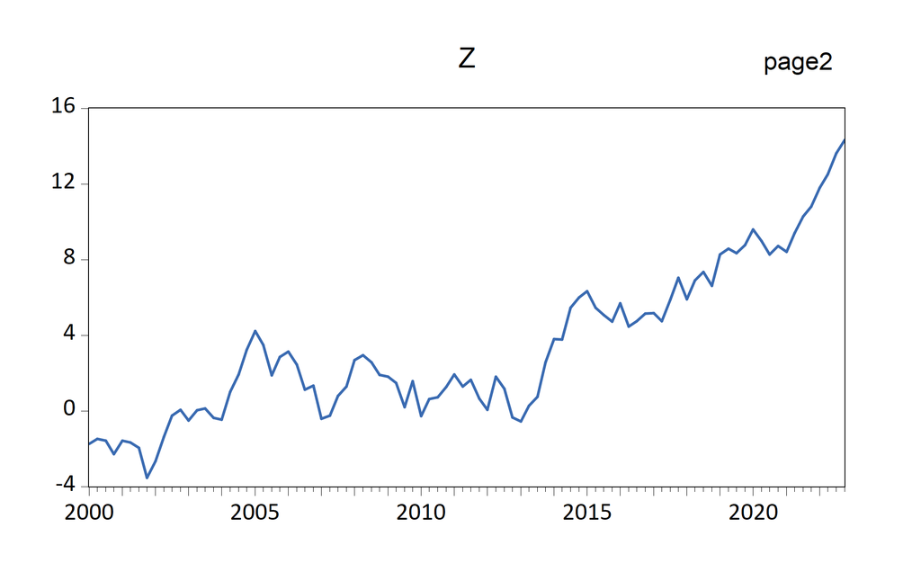

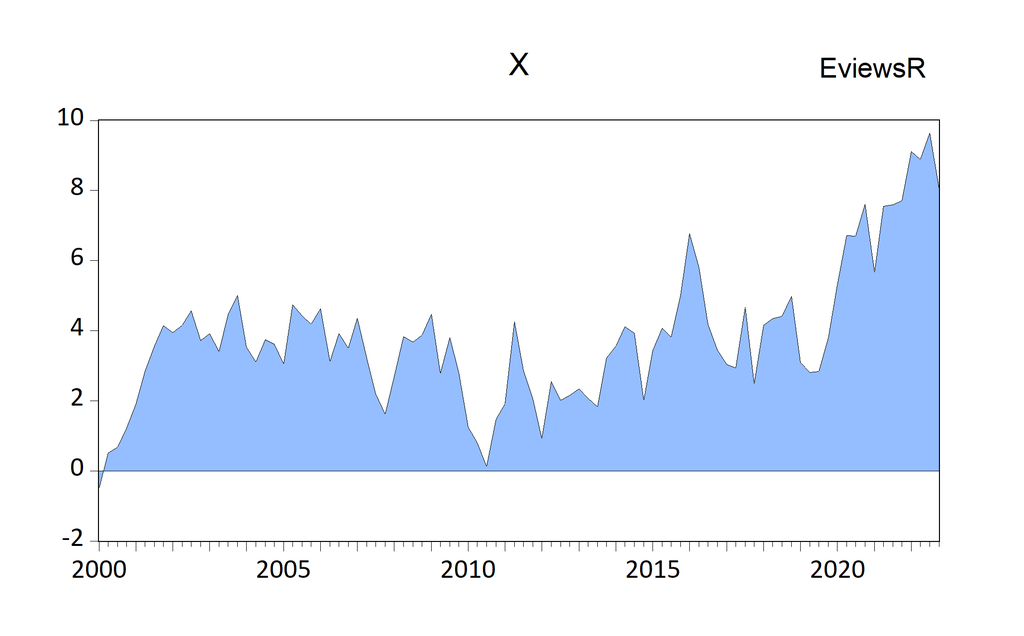

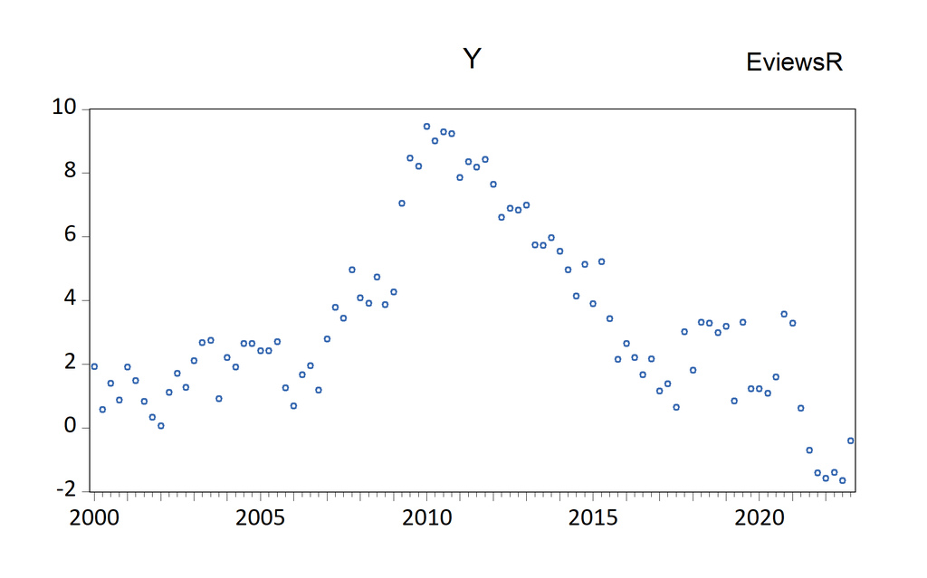

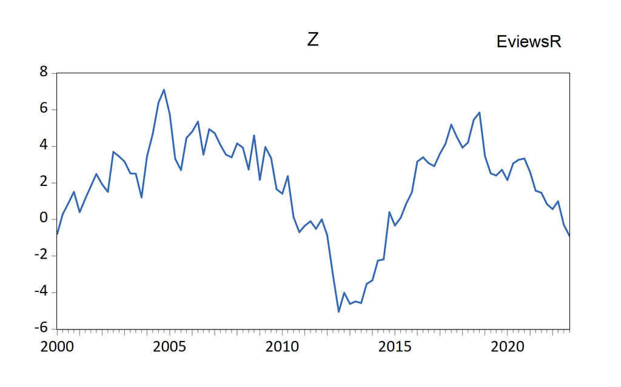

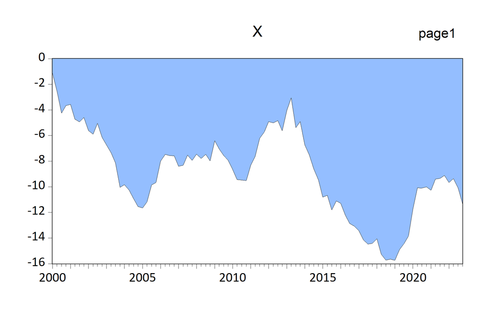

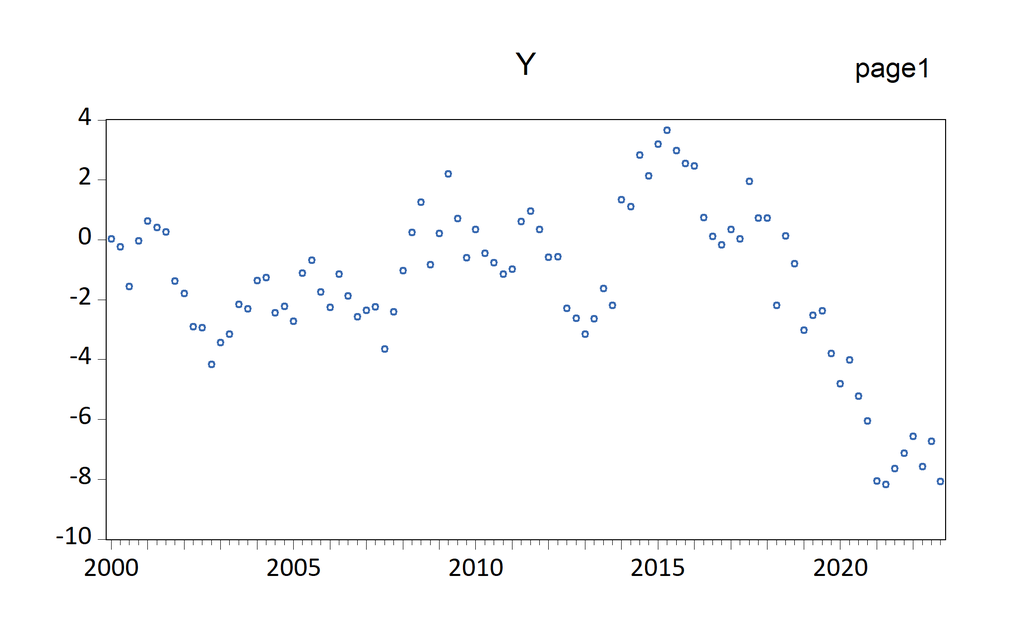

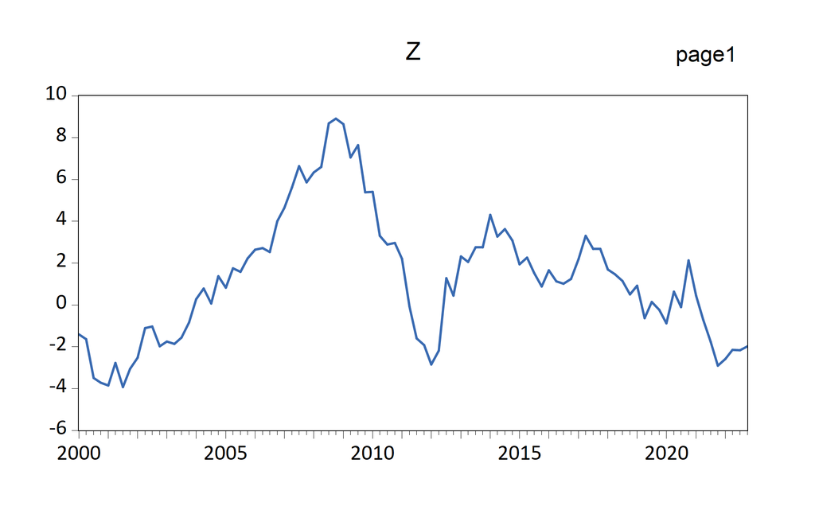

EViews graphs automatically imported by EViews chunk (fig-EviewsR1: default chunk options)

On the other hand, some data members of the EViews `equation` objects are extracted and imported into the new environment as a dataframe. Data member’ is an EViews term for statistics, summaries, and information criteria related to EViews `equation` objects. The code below shows the general way to access the imported equation object, where `equationName` is the EViews equation object. The page and equation names are separated by underscore (`_`). The data members of the equation objects can be accessed via standard list element access syntax:

- `chunkLabel$pageName_equationName$dataMember`

For example, the $R^2$ value of the OLS equation object on `EviewsR` page is 0.402377, which can be accessed using the inline expression `` `r EviewsR1$eviewsr_ols$r2` ``.

Note that `@coefs`, `@pval`, `@stderrs` and `@tstats` return vectors with length equal to the number of estimated coefficients. The second value of each of these vectors can be accessed with typical square bracket notation, i.e. by appending `[2]`. The rest of the data members return scalar values. The number of data members reported by the EviewsR package is greater than that provided by `lm()`, `glm()` and `summary()` R functions. For example, R users need to use more functions or lines of code to get the values of Schwarz and Hannan-Quinn Information Criteria of an estimated model. These values are automatically imported into R, R Markdown or Quarto environment by the EviewsR package.

The graph objects are saved on disk to the path defined by the chunk option `fig.path` and can be captioned and sub-captioned via the chunk options `fig.cap` (`fig-cap`) and `fig.subcap` (`fig-subcap`) in an R Markdown (Quarto) document. The graph file on the disk are named in the following format:

- `chunkLabel-pageName-graphName`

For example, `eviewsr1-page2-graph1` is the name of `graph1` object of `page2` created in `fig-EviewsR1` chunk.

The series objects of each page can be fetched through

- `chunkLabel$pageName`.

For example, `EviewsR1$page2` provides the dataframe of all the series objects on `page2`. Even if the page is not defined in the created or imported workfile, EViews names both the workfile and page as `untitled` by default. So `EviewsR1$untitled` is the right way to access the series object, if no page name is defined in the `fig-EviewsR1` chunk.

By default, imports the series objects as a dataframe with date column formatted as `POSIXct` . We can import the series objects as `xts` object by setting chunk option `class="xts"`.

Note that the chunk label is case-sensitive, while the EViews equation, series and table objects are not. They can be in capital letters in the chunk, but they are in lowercase in the R object. This is because R variable names are case-sensitive, while EViews objects are not. For consistency, is designed to convert EViews object names to lowercase. Therefore, we recommend naming EViews objects with lowercase names.

The graph objects in Figure @ref(fig:fig-EviewsR1-1) are imported with the default chunk options. We can use chunk options `page`, `graph` and `graph_procs` to change the behaviour of the graphical outputs. The chunk option `page` can take `page="*"`, or a space-delimited (or a vector of) string wtih the names of EViews pages. Note that we ask EViews to write the page name on the top right corner of each graph. The chunk option `graph` can have the values such as `*`, `first`, `last`, `asis`, `asc`, `desc` or a numeric vector.

## Importing EViews graph asis

We set these chunk options to get Figure @ref(fig:fig-EviewsR2-1).

- `graph: "@asis"`
- `graph_procs: template newspaper`

The option `graph: "@asis"` makes sure that the graph objects are imported in the order they appear in the EViews chunk, that is `graph3` followed by `graph2` and `graph1`. This option is only useful in an R Markdown or Quarto document:

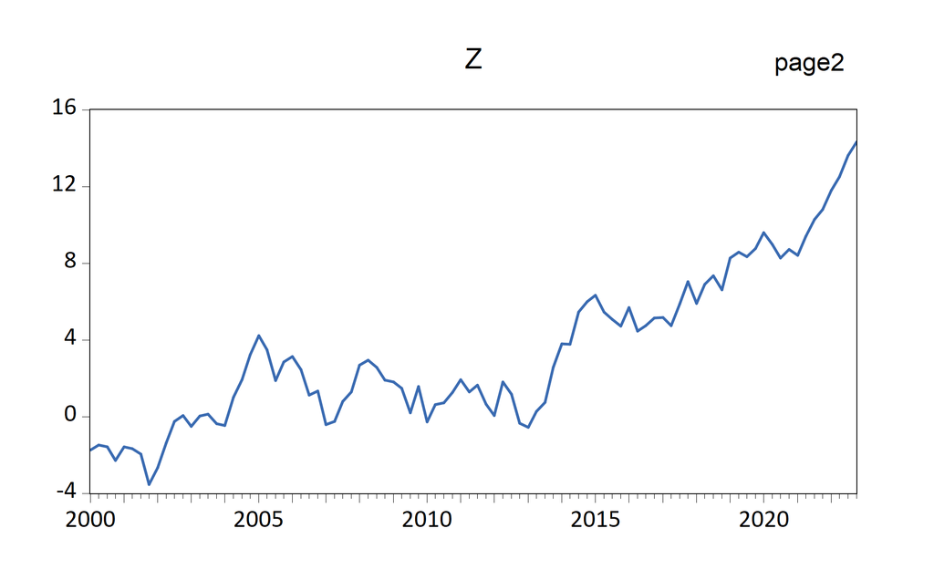

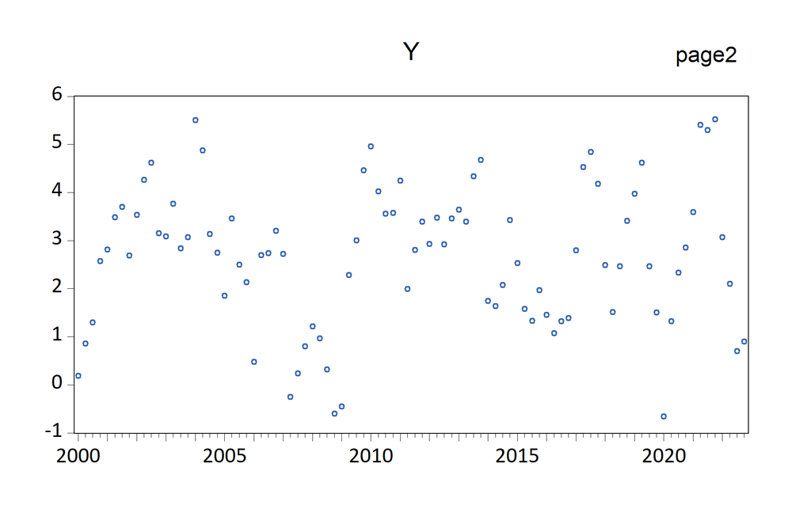

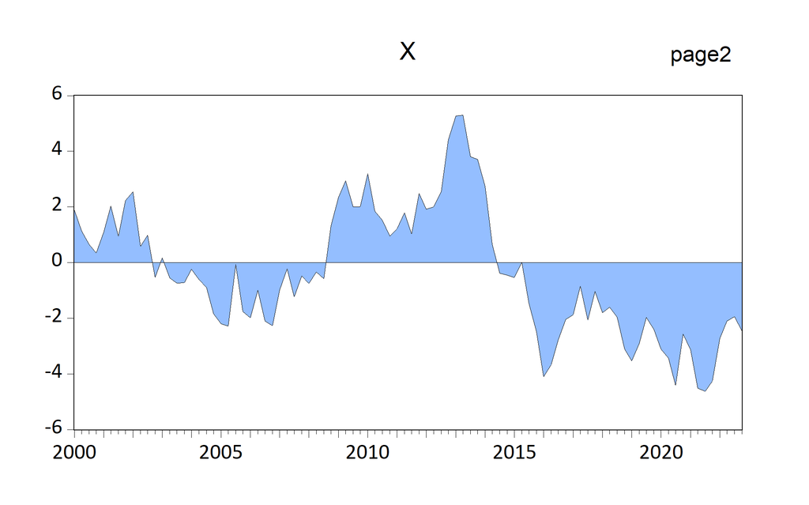

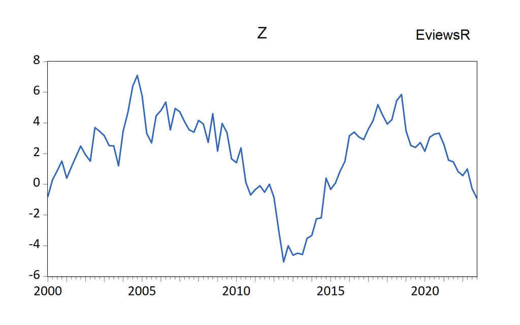

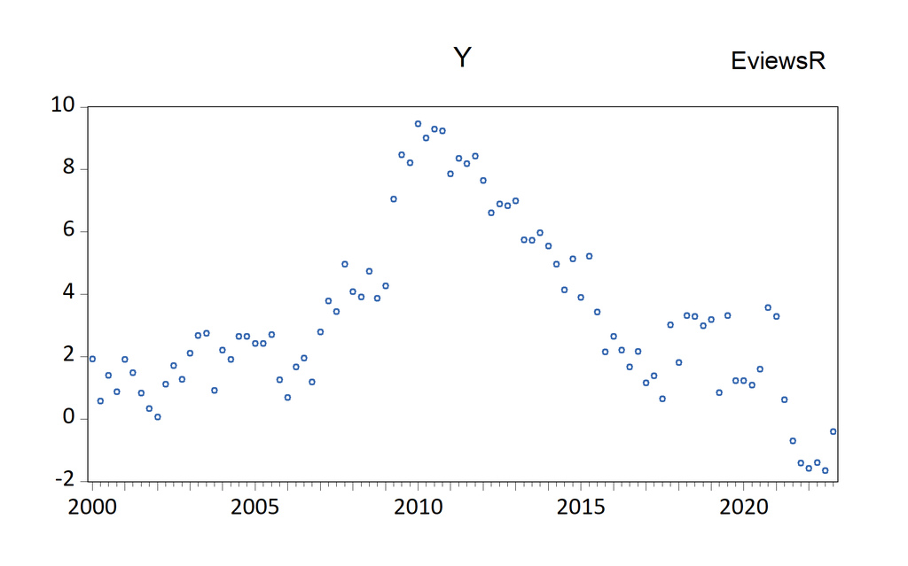

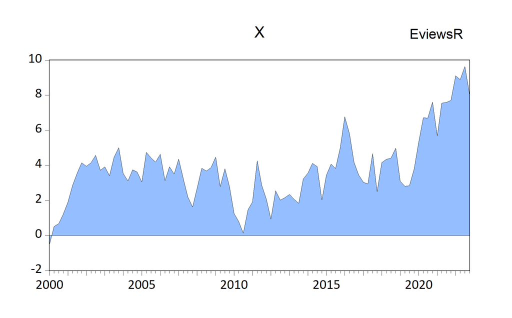

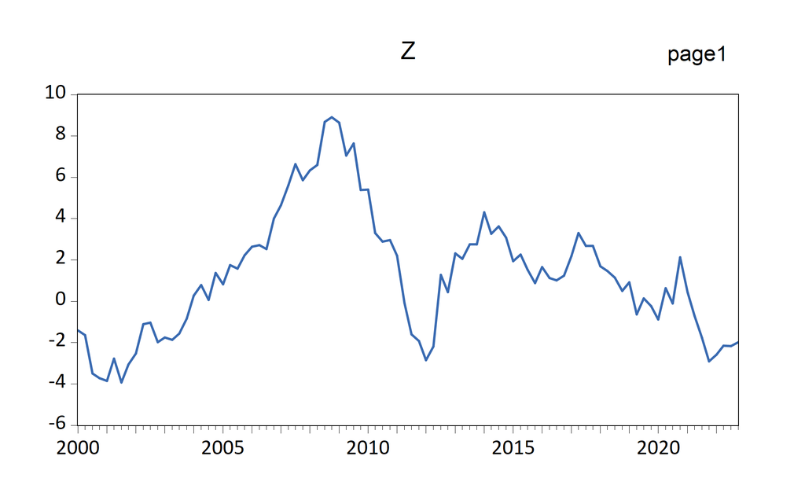

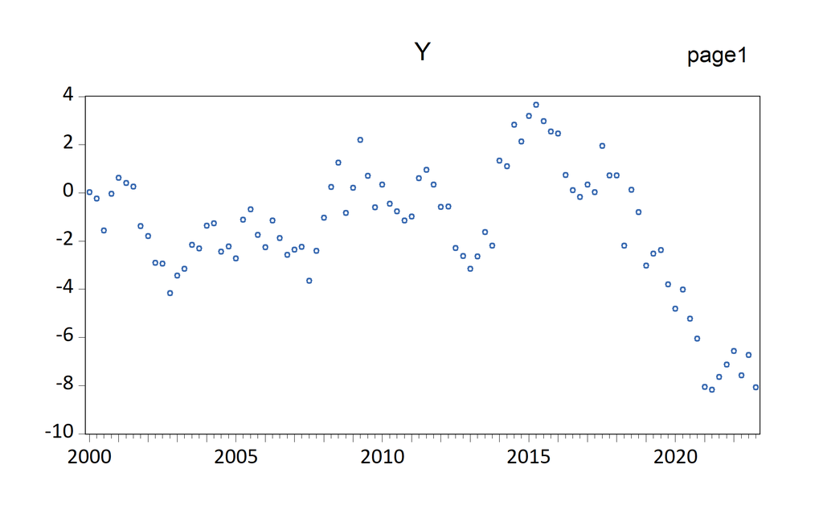

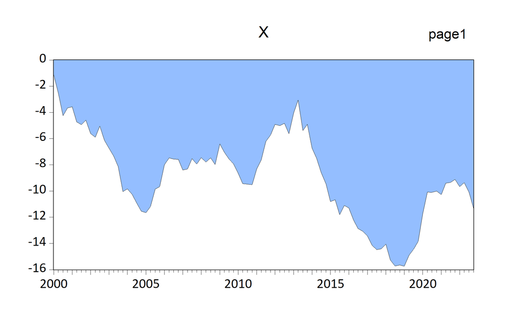

EViews graphs automatically imported by EViews chunk (fig-EviewsR2)

## Use of graph_procs chunk option

To plot Figure @ref(fig:fig-EviewsR3-1), include the following arguments in the chunk options:

- `graph_procs: [template bokeh, setelem(1) lcolor(green) fillcolor(green)]`
- `graph: "@asis"`
- `page: eviewsr page1`

Note that only the graph objects from pages `EviewsR` and `page1` are included.

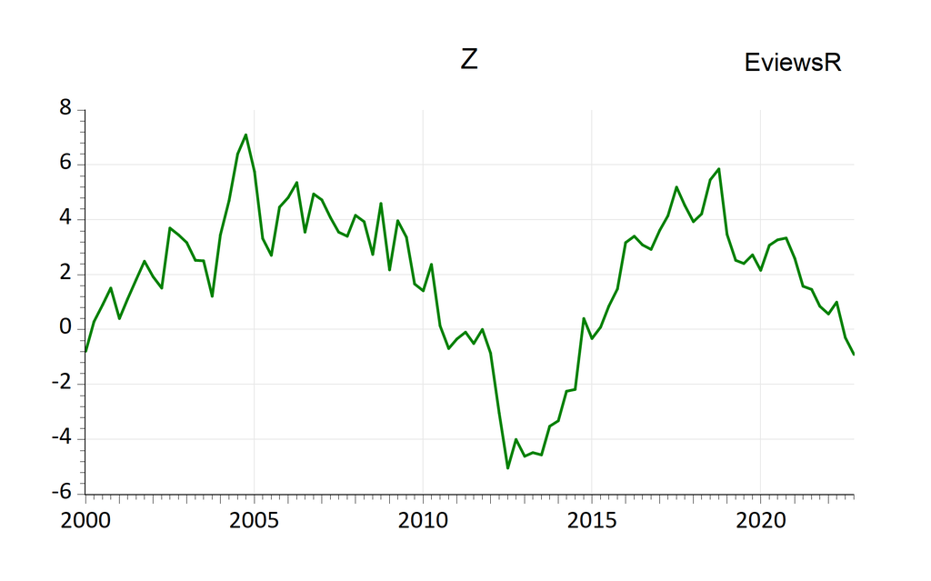

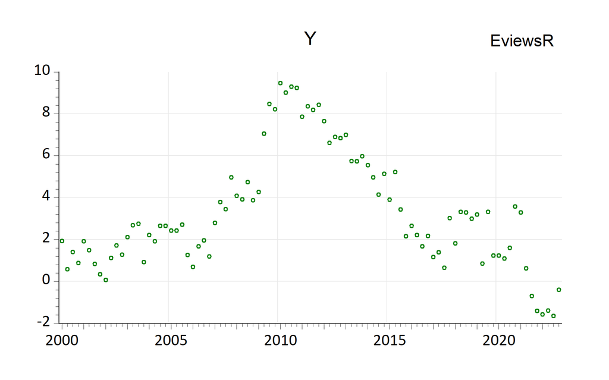

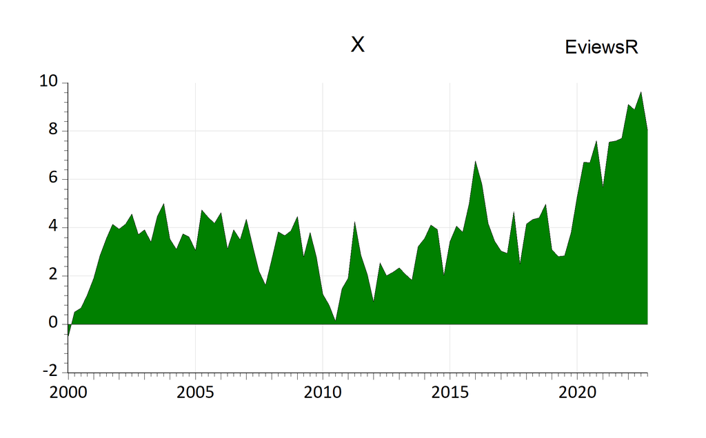

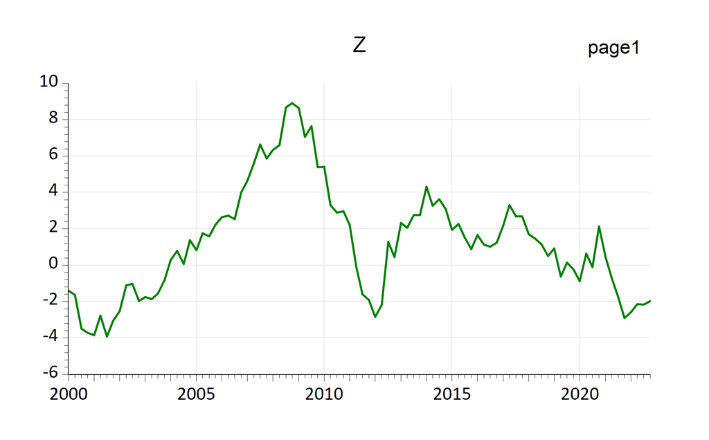

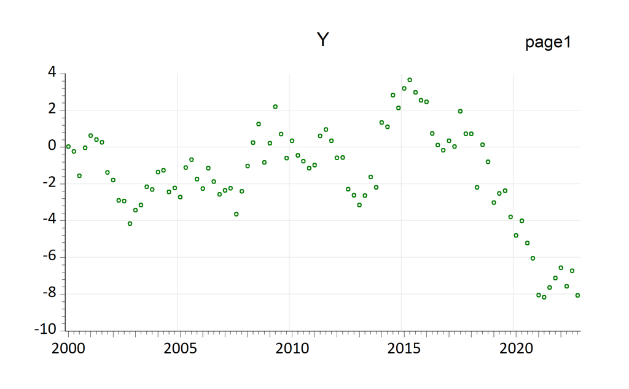

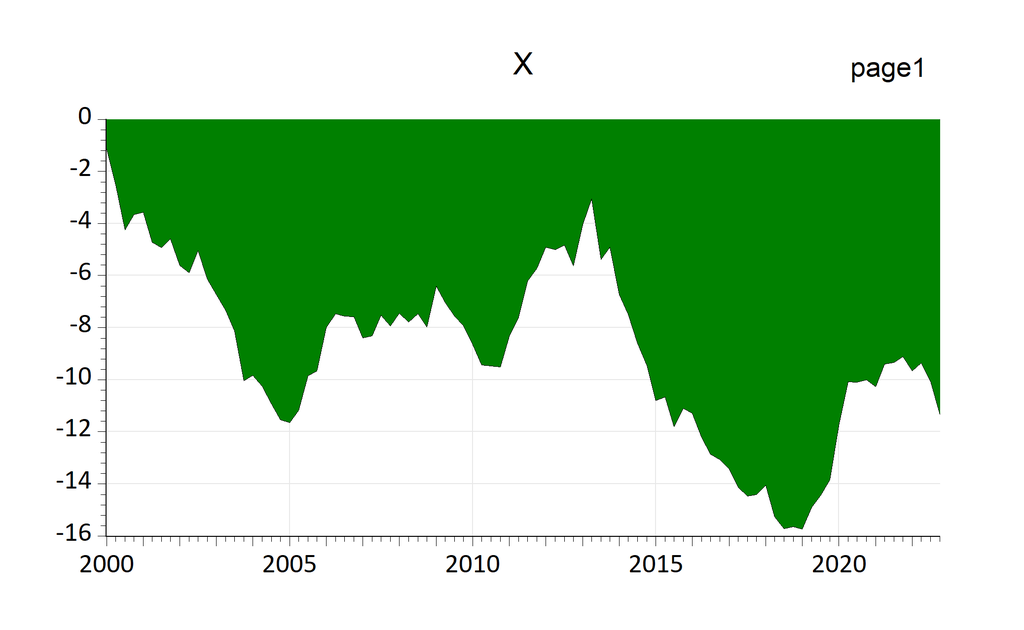

EViews graphs automatically imported by EViews chunk (fig-EviewsR3)

## Importing only the first graph

To plot only the first graph object from each of the EViews pages, after all the graph objects on each page are arranged in ascending order. Therefore only a combination of `graph1` object from each of the pages is plotted as shown in Figure @ref(fig:fig-EviewsR4-1):

- `graph_procs: [template modern,datelabel format("YYYY"),setelem(1) fillcolor(red)]`
- `graph: "@first"`

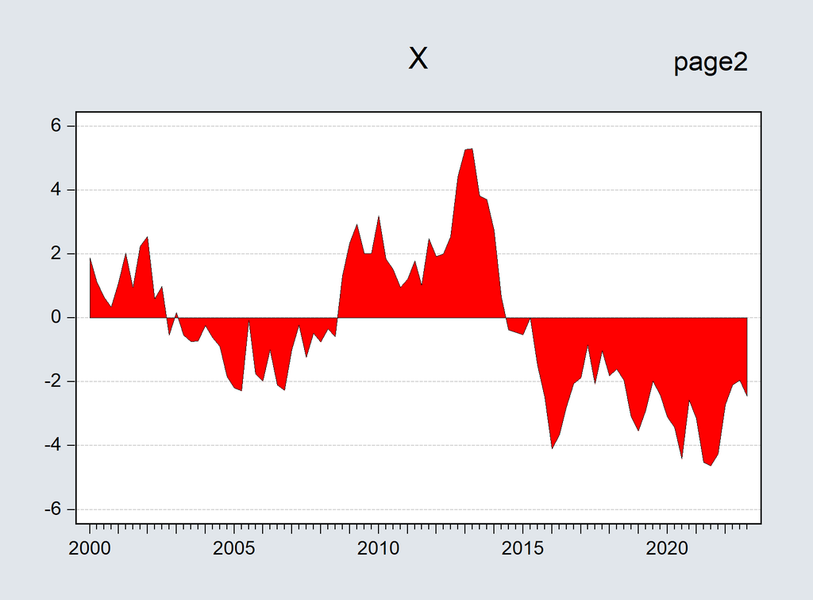

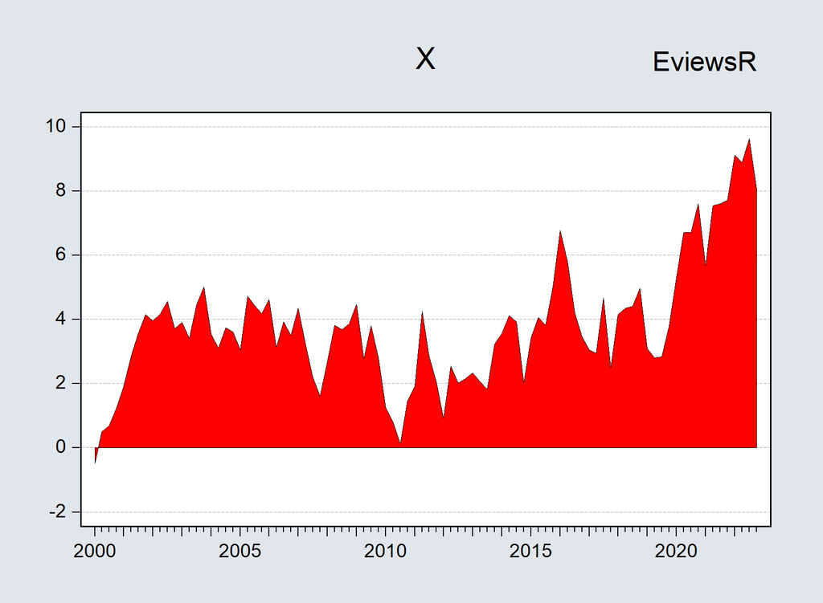

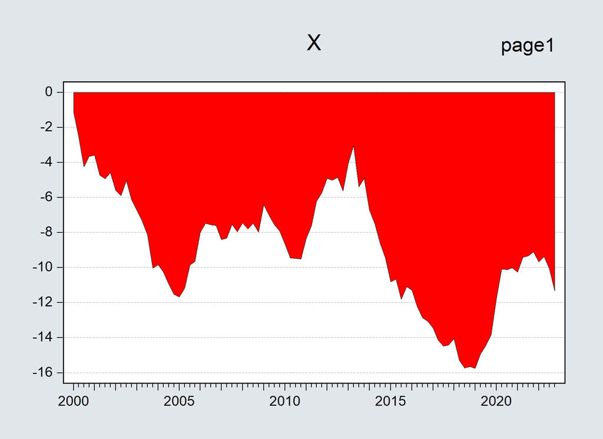

Importing only the first EViews graphs by EViews chunk (fig-EviewsR4)

## Importing only the last graph

The chunk option `graph: "@last"` is the direct opposite of the `graph: " @first"` as it considers the last graph object only.

- `graph: "@last"`

## Importing only graphs selected by index

We modify the chunk options as follows to ensure that only the second, fifth and eighth graph objects across all pages, are included in the output. Therefore only `graph2` object from each of the pages is considered.

- `graph: [2,5,8]`

## Importing graphs in ascending/descending order

We arranges all the graph objects across all the pages in ascending order by setting:

- `graph: "@asc"`

We can also import the graphs in descending order by:

- `graph: "@desc"`

# EviewsR: base R functions

To work with EViews, a workfile and a workfile page are required, therefore we add `wf` (workfile) and `page` (workfile page) arguments for each function. These functions are explained as follows:

## The create_object() function.

The function `create_object()` can be used to create an EViews object in the existing EViews workfile. We can use the EViews workfile (`EviewsR.wf1`) created by the EViews chunk in Section @ref(sec-document). The complete EViews syntax for an object command has the form:

```
EViews> action(action_opt) object_name.view_or_proc(options_list) arg_list

EViews> object_type(options) object_name[=expression]
```

Where `action` can be one of the four EViews commands (`do`, `freeze`, `print`, `show`); `action_opt` modifies the default behaviour of the `action`; `object_name` is any arbitrary character string to represent the name of the EViews object to be acted upon; `view_or_proc` stands for the EViews object’s view or procedure to be performed; `options_list` is the option for the `view_or_proc`; `arg_list` stands for the EViews view or procedure arguments.

To create an equation object `eviews_equation` as an `ar(1)` process on `EviewR1` page of `EviewsR.wf1` workfile, we can use the following EViews code:

```
EViews> wfopen EviewsR_files/EviewsR
EViews> pageselect EviewsR1
EViews> equation eviews_equation.ls y ar(1)
EViews> wfsave EviewsR_files/EviewsR
```

The above can be translated into base R function as:

```r
R> create_object(wf = "EviewsR_files/EviewsR", page = "EviewsR1",
+     action = "equation", object_name = "eviews_equation", view_or_proc = "ls",
+     arg_list = "y ar(1)")
```

To create a series object `series1` and assign it to the square of $y$ series on `EviewsR2` page of `EviewsR.wf1` workfile:

```
EViews> wfopen EviewsR_files/EviewsR
EViews> pageselect EviewsR2
EViews> series series1=y^2
EViews> wfsave EviewsR_files/EviewsR
```

```r
R> create_object(wf = "EviewsR_files/EviewsR", page = "EviewsR2",
+     object_type = "series", object_name = "series1", expression = "y^2")
```

## The eviews_graph() function

EViews graph can be included in an R Markdown or Quarto document by `eviews_graph()` function. This function is a blend of EViews `freeze`, `graph` and `save` commands. The following are the EViews syntaxes:

```
EViews> freeze(options, name) object_name.view_command
EViews> graph graph_name.graph_command(options) arg1 [arg2 arg3 ...]
EViews> graph_name.save(options) [path\]file_name
```

The first and second syntaxes can be merged to produce another syntax which we use to create the `eviews_graph()` function. So the new syntax is:

```
EViews> freeze(options, name) object_name.graph_command(options)
```

Each of the `freeze`, `graph_command` and `save` commands has an `options` keyword. We use `mode` for `freeze` command options, `graph_options` for `graph_command` command options, and `save_options` for `save` command options. Check EViews manual for all the available options for these commands.

The `series` argument can be the names of EViews series objects or an R dataframe. If `series` is a set of EViews series objects, `wf` and `page` need to be specified. If `series` is an R dataframe, `wf` and `page` are optional.

To create figures of series objects x and y saved on `EviewsR` page of the `EviewsR.wf1` workfile:

```
EViews> wfopen EviewsR_files/eviewsr
EViews> pageselect eviewsr
EViews> freeze(eviewsGraph_x,mode=overwrite) x.line
EViews> freeze(eviewsGraph_y,mode=overwrite) y.line
EViews> for %y eviewsGraph_x eviewsGraph_y
EViews> {%y}.axis(l) font(Calibri,14,-b,-i,-u,-s)
EViews> {%y}.axis(r) font(Calibri,14,-b,-i,-u,-s)
EViews> {%y}.axis(b) font(Calibri,14,-b,-i,-u,-s)
EViews> {%y}.axis(t) font(Calibri,14,-b,-i,-u,-s)
EViews> {%y}.legend columns(5) inbox position(BOTCENTER) font(Calibri,12,-b,-i,-u,-s)
EViews> {%y}.options antialias(on)
EViews> {%y}.options size(6,3)
EViews> {%y}.options -background frameaxes(all) framewidth(0.5)
EViews> {%y}.setelem(1) linecolor(@rgb(57,106,177)) linewidth(1.5)
EViews> {%y}.setfont legend(Calibri,12,-b,-i,-u,-s) text(Calibri,14,-b,-i,-u,-s)
EViews> {%y}.setfont obs(Calibri,14,-b,-i,-u,-s)
EViews> {%y}.textdefault font(Calibri,14,-b,-i,-u,-s)
EViews> {%y}.save(t=pdf) {%y}
EViews> next
```

Note that the EViews `for loop` in the code above contains the default values of EViews graph procedures provided by package. It can be found in the `eviews_graph()` function’s skeleton defined as `graphicsDefault`. We will avoid repeating the default values and use ‘insert default values’ instead. These default values can be modified or replaced entirely by using `graph_procs` argument. For example the line colour of the first graph element is blue by default. This can be changed to red by setting `graph_procs="setelem(1) linecolor(red)"`, which overwrites the default “`setelem(1) linecolor(@rgb(57,106,177))`”. We can also overwrite the default behaviour by setting any available EViews templates, for example `graph_grocs="template defaults"`, which resets the graph objects to EViews global graphics defaults.

The EViews code above can be easily written as an R chunk to produce Figure @ref(fig:fig-eviewsGraph) as follows:

````
```{r}
#| label: fig-eviewsGraph
#| fig.cap: EviewsR example figure using \LaTeX{} subfig package
#| fig.show: hold
#| out.width: 45%
#| out.height: 15%
#| eval: TRUE

eviews_graph(series="x y",wf="EviewsR_files/EviewsR",page = "EviewsR",save_options="t=pdf")

```
````

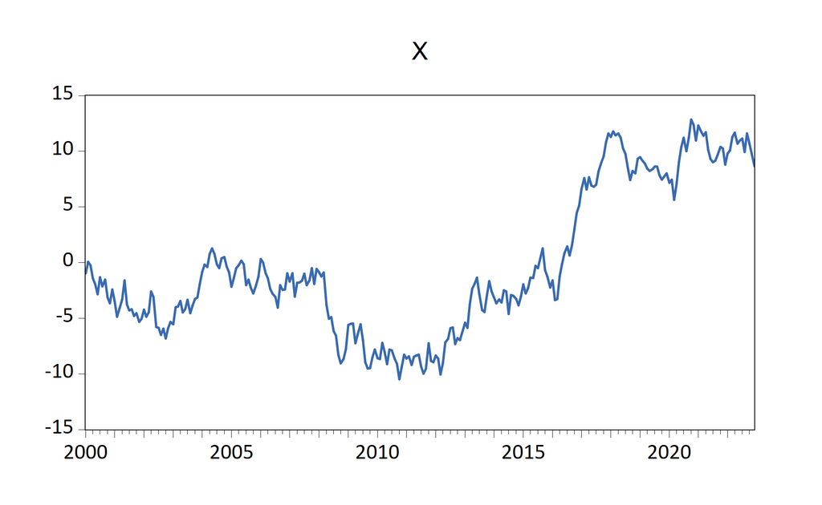

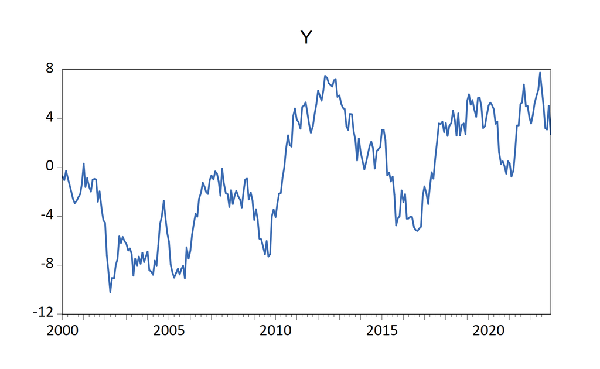

EviewsR example figure using subfig package

To produce EViews graphs aligned in two columns, as in Figure @ref(fig:fig-eviewsGraph1), from an R dataframe named `EviewsRDataFrame`:

- Use R’s `write.csv()` function to write the dataframe as a CSV file.

```r
R> write.csv(EviewsRDataFrame, "csvFile.csv", row.names = FALSE)
```

- Use EViews to import the `csvFile.csv`, then create and save the graphs on disk:

```
EViews> import csvFile.csv @freq m start_date=1990
EViews> group some_group x y
EViews> freeze(eviewsGraph1_xy,mode=overwrite) some_group.line(m)
                    insert default values
EViews> eviewsGraph1_xy.axis(b) angle(45) font(b)
EViews> eviewsGraph1_xy.save(t=png,d=300) eviewsGraph1_xy
```

- Use ’s `include_graphics()` function to import the graph into the R Markdown or Quarto document.

The values provided by `graph_procs` argument are appended to the graph’s default values. Therefore, `graph_procs` overwrites the existing default value of the EViews graph procedures.

We use the following options to modify the figure:

- `group=TRUE`
- `graph_options="m"`
- `graph_procs="axis(b) angle(45) font(b)"`

````
```{r}
#| label: fig-eviewsGraph1
#| fig.cap: "EViews graph from dataframe (chunk: fig-eviewsGraph1)"
#| out.width: 90%
#| out.height: 15%
#| eval: true

eviews_graph(series=EviewsRDataFrame,start_date = "1990",group=TRUE,
graph_options="m",graph_procs="axis(b) angle(45) font(b)")
```
````

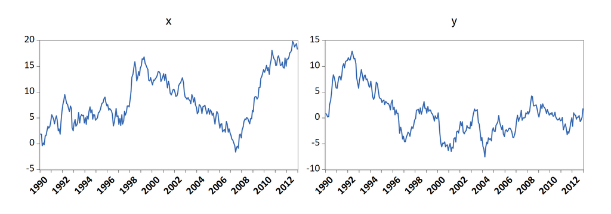

EViews graph from dataframe (chunk: fig-eviewsGraph1)

To create a scatterplot along with histogram on each axis border using green colour (#008753 hex code):

```
EViews> wfopen EviewsR_files/eviewsr
EViews> pageselect eviewsr
EViews> group some_group x y
EViews> freeze(eviewsGraph2_xy,mode=overwrite) some_group.scat(ab=histogram) linefit()
                    insert default values
EViews> eviewsGraph2_xy.setelem(1) lcolor(@hex(008753))
EViews> eviewsGraph2_xy.save(t=png,d=300) eviewsGraph2_xy
```

The equivalent R chunk to produce Figure @ref(fig:fig-eviewsGraph2):

````
```{r}
#| label: fig-eviewsGraph2
#| fig.cap: EViews graph from dataframe
#| out.width: 90%
#| out.height: 40%
#| eval: TRUE

eviews_graph(series="x y",wf="EviewsR_files/EviewsR",page="EviewsR",
graph_command="scat(ab=histogram) linefit()",group=TRUE,
graph_procs='setelem(1) lcolor(@hex(008753))')
```
````

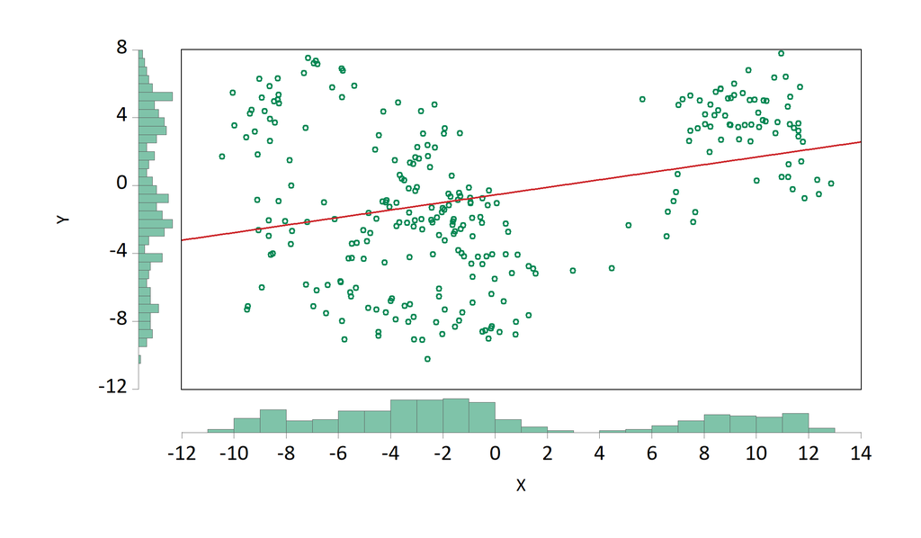

If we want to plot all the series objects contained in `EviewsR2` page of `EviewsR.wf1` workfile that lives in `EviewsR_files/` folder, we can simply use:

```r
R> eviews_graph(wf = "EviewsR_files/EviewsR", page = "EviewsR2")
```

Note that we have not specified the `series` argument as `eviews_graph()` function is designed to plot all series objects by default. Similarly, we do not need to provide the `page` argument if we intend to include the graphs of all the series objects from all the pages of the workfile. We can also use any valid EViews wildcard expressions or pattern, such as `series="x*"`, `series="???x"` and so on.